# Tour of HippoLinTools

Marion Betizeau

November 30, 2017

## Installation

I assume that you have R and Rstudio installed on your machine. If not check out https://cran.r-project.org/ and https://www.rstudio.com/products/rstudio/download/ choose the free desktop version.

For Windows user install Rtools https://cran.r-project.org/bin/windows/Rtools/.

From Neurogenesis/Marion/HippoLinTools download the file “HippoLinTools.zip”. Unzip the file and open `HippoLinTools.Rproj` with R studio. In the top right window select the Build tab, click on Build & Reload ; see below).

[figure not shown]

Once this is done and you do not get any error. Close R studio and start a new session.

Install the following packages, by executing these lines in your console:

```r
install.packages("devtools")
install.packages("roxygen2")
install.packages("knitr")
install.packages("igraph")
install.packages("lattice")
install.packages("pheatmap")
install.packages("RColorBrewer")
install.packages("plotrix")
install.packages("beeswarm")
install.packages("dae")
install.packages("grid")
install.packages("FactoMineR")
install.packages("ggfortity")
install.packages("ade4")
install.packages("Hmisc")
install.packages("ggplot2")
```

If you do not get any error message, **congrats** you just installed all the required packages.

Now let’s charge it in memory to be able to use it! And also all the other packages that you just installed.

```r
library(HippoLinTools)

library(beeswarm)
library(dae)
library(igraph)
library(lattice)
library(pheatmap)
library(grid)
library(RColorBrewer)
library(ggfortify)
library(ade4)
library(plotrix)
library(ggplot2)
library(knitr)
library(Hmisc)
library(ggbeeswarm)
```

## Groups of functions

To see the list of functions in the package, go the the lower righ part of RStudio and to the Packages Tab, look for HippoLinTools and click on it.

### Functions for building the table using individual ROI tables

1. Processing of .txt or .csv ROI files
- `decodeROIData` for Hippocampal Lineage
- `decodeROIDataDevelopment` for Cortical development Lineage

For more info look at the help file by executing the appropriate line:

```r
?decodeROIData
?decodeROIDataDevelopment
```

Note that there are examples of use of these function at the botton of the help file. Let’s do the example for `decodedData`

```r
# Gets the path to the files saves in the packages
myCorrespondencePath <- paste(system.file("extdata", "Correspondence_TimePoint_DPI", package = "HippoLinTools"),"/", sep = "")
myRoiPath <- paste(system.file("extdata", "ROI", package = "HippoLinTools"),"/", sep = "")
# Use the files
decodedDataExample <- decodeROIData(ROIpath = myRoiPath, DPITimePointPath = myCorrespondencePath)
summary(decodedDataExample)
View(decodedDataExample)
```

Note that there are datasets already saved in the package so that you can have examples of the different tables. They are listed along the functions in the summary page of the package, and contain the suffix “example”.

```r
# To get help on the dataset:
?HippoLinTools::decodedDataExample

# To access the dataset:
decodedDataExample <- HippoLinTools::decodedDataExample
```

2. `neuronAssignment` : Assign Neurons/Neuroblasts as certain if observed long enough. Might work only for Hippocampal Linages so far.

```r
?neuronAssignment
```

Run the example and check out what happened. It might be easier to see what happened using the plot lineage functions.

### Functions for visualization of lineages

There are several functions to visualize lineages For hippocampus lineages : `plotLineage`, `plotLineage2`

For cortical lineages: `plotLineageDevelopment`

`?plotLineage` `?plotLineage2`

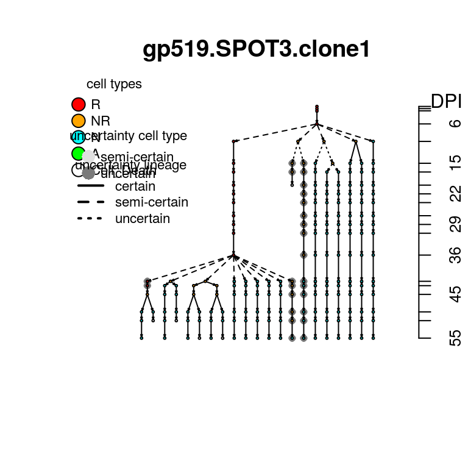

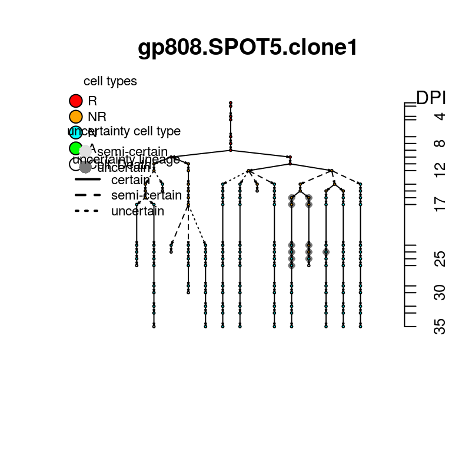

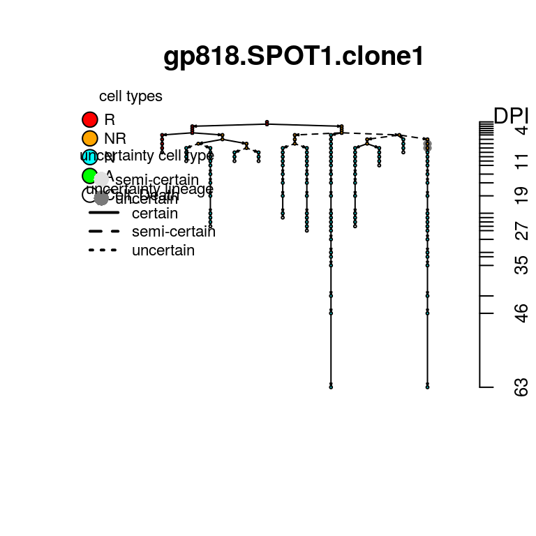

```r
# One circle per time point
plotLineage2(decodedData = decodedDataExample, saveGraph = F, displayLabels = F, myFileName = "Rlineages.pdf")
```

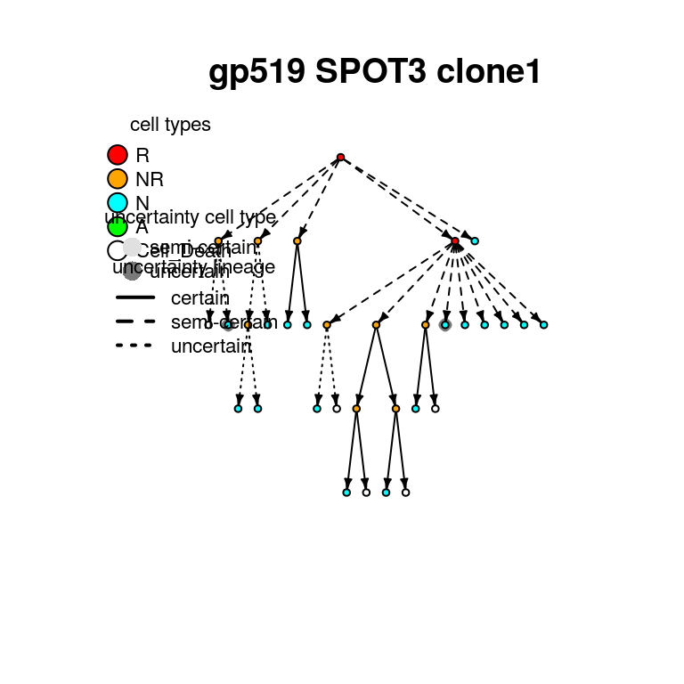

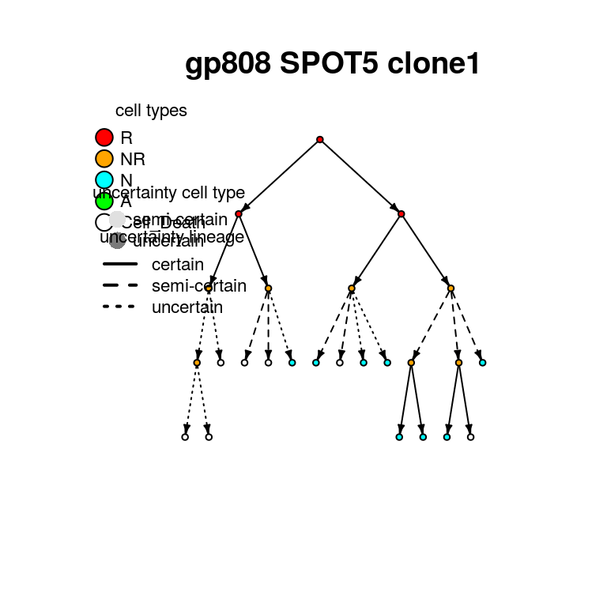

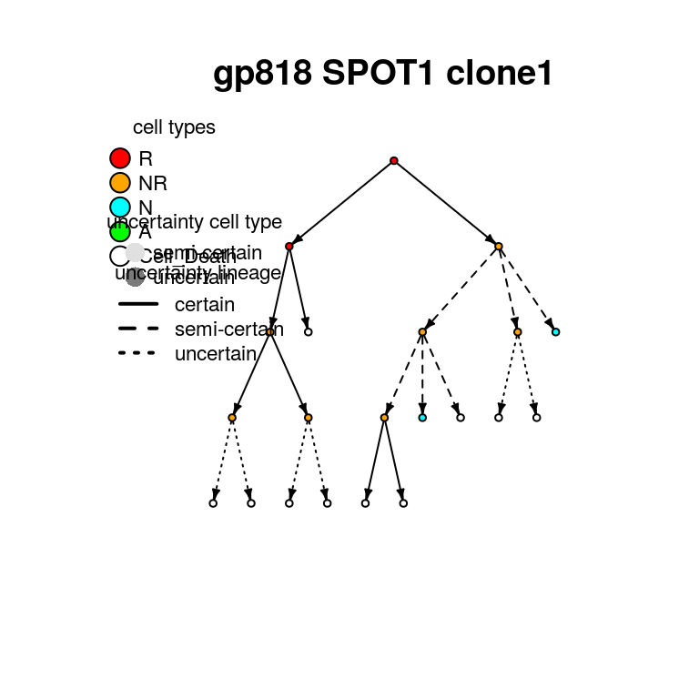

```r
# One circle per cell
plotLineage(decodedData = decodedDataExample, saveGraph = F, displayLabels = F, myFileName = "Rlineages.pdf")
```

### Data table per time point : dataTp

The decodedData table contains one row per cell per time point, basically the full set of information. For some purposes, one needs to select only the relevent information.

Let’s assume we want to display the number of R, NR and neurons over time per lineage. In this case, one needs to have one row per time point per lineage. For each time point, there is a function `transformTreeIntoTp` that sums up how many R, NR and neurons there are in the lineage.

Get the help to have a look how `transformTreeIntoTp` works.

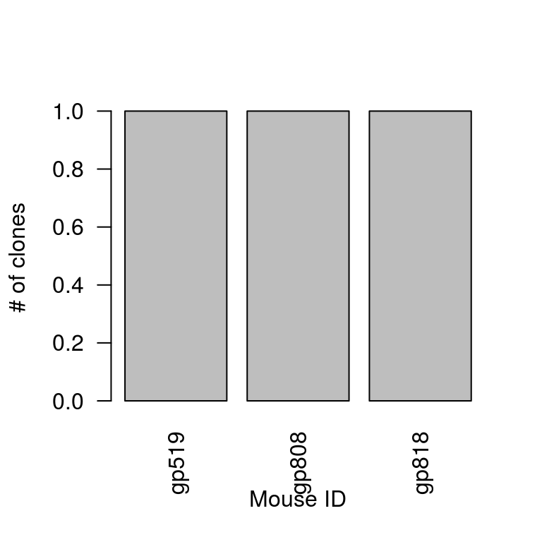

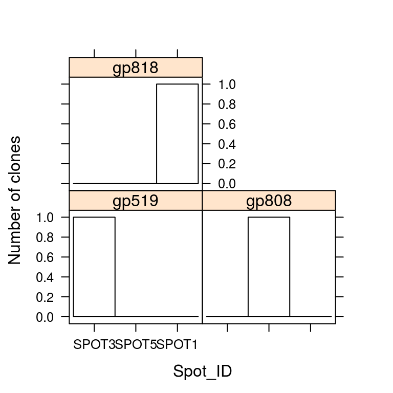

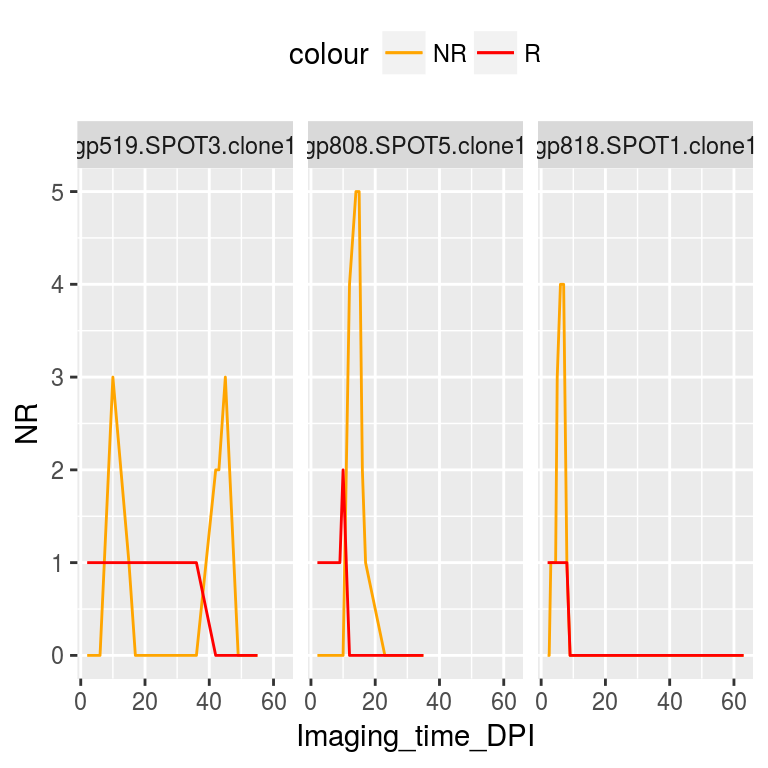

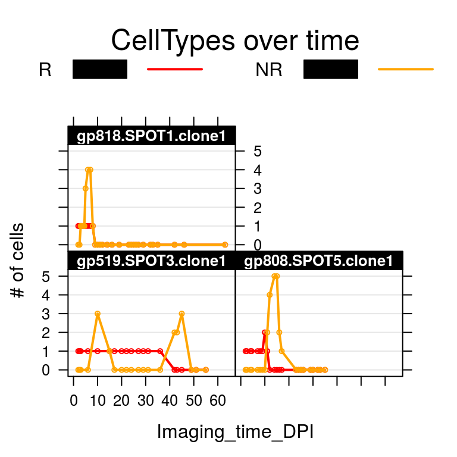

```r
myLegend <-  c("R","NR","N","A","Cell_Death","Uncertain")
dataTp <- transformTreeIntoTp(data2Transform = decodedDataExample, namesTypes = myLegend, displayPlot = T)


# Plotting cell number evolution over time: one lineage per plot
  ## Using ggplot2
myplot <- ggplot(dataTp , aes(x=Imaging_time_DPI)) +
                geom_line(aes (y = NR, color = "NR")) +
                geom_line(aes (y = R, color = "R")) +
                facet_wrap(~Clone_uniqueID) +
                scale_color_manual(values=c('orange','red'))+
                theme(legend.position="top")
myplot # Displays the graph



  ## Using lattice (For your information but no necessary to go into details)
myColors <- c("red","orange","cyan","green","black", "purple")

my.settings <- list(superpose.symbol=list(col=myColors),
                    superpose.line=list(col=myColors, lwd = 2),
                    strip.background=list(col="black")) #,
                   # strip.border=list(col="black"))

xyplot(R + NR ~ Imaging_time_DPI | Clone_uniqueID, data = dataTp,
       ylab = "# of cells", type= 'b', cex= 0.5,
       auto.key= list(space= "top", columns = 2, rectangle = FALSE, title = "CellTypes over time", lines = TRUE, points = FALSE),
       par.settings = my.settings,
       par.strip.text=list(col="white", font=2,cex= 0.8),
       panel=function(x,y,...){
         panel.grid(h=-1, v=0);
         panel.xyplot(x,y,...)
       })
```

For more info about how ggplot2 works check out: http://www.sthda.com/english/wiki/ggplot2-essentials.

If one wants to display the lineage of a particular mouse:

```r
dataTpgp818 <- dataTp[dataTp$Mouse_ID == "gp818", ] # Filters the data : data[ rows, columns], here taking only the rows for which the mouseID is "gp818"
summary(dataTpgp818$Mouse_ID) # Check that the dataset contains only data from gp818
```

```
## gp519 gp808 gp818
##     0     0    29
```

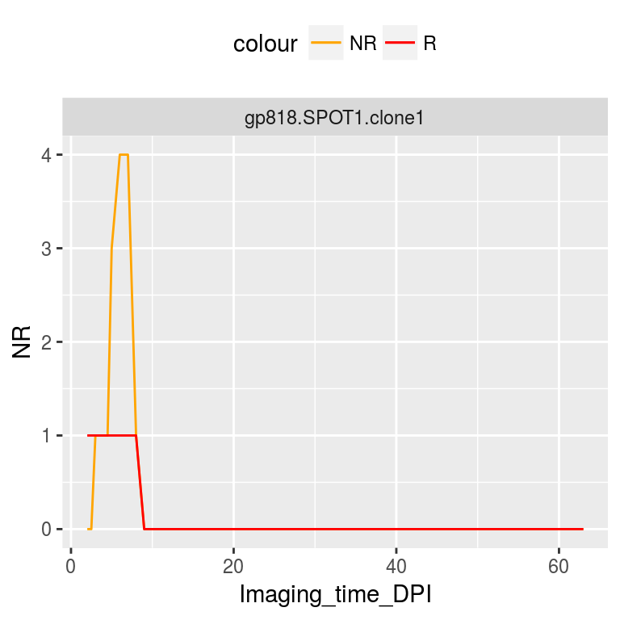

```r
# Plotting cell number evolution over time: one lineage per plot only gp 818 lineages
  ## Using ggplot2
myplot <- ggplot(dataTpgp818, aes(x=Imaging_time_DPI)) +
                geom_line(aes (y = NR, color = "NR")) +
                geom_line(aes (y = R, color = "R")) +
                facet_wrap(~Clone_uniqueID) +
                scale_color_manual(values=c('orange','red'))+
                theme(legend.position="top")
myplot # Displays the graph
```

Another useful function to look at the final composition of clones and the final numver of cells

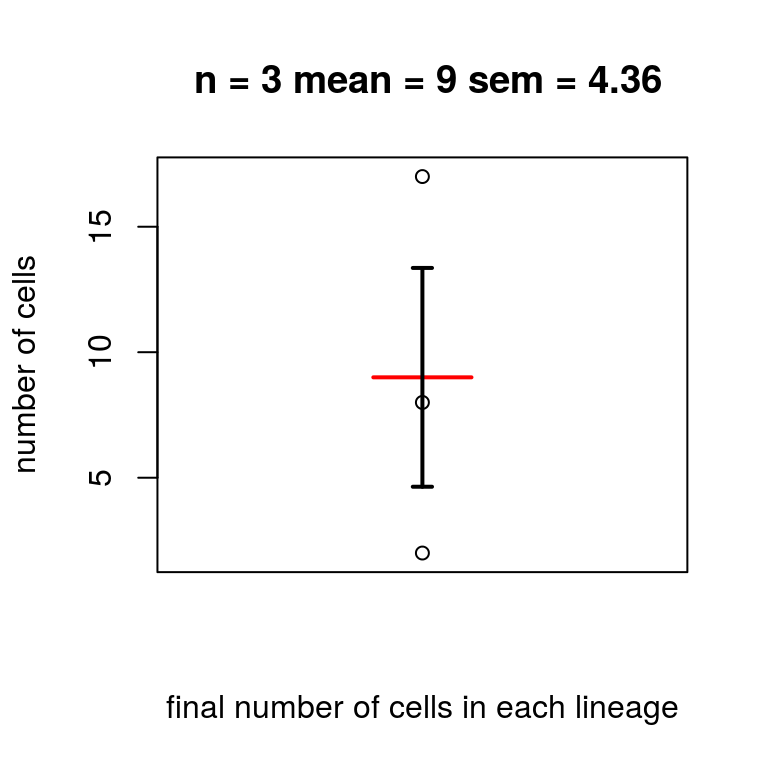

```r
finalComposition <- cloneOutcome(dataTp)
barPlotBeeswarm(myData = finalComposition$TotalCellNumber, ylab = "number of cells", xlab = "final number of cells in each lineage")
```

### Min Max tables

For other purposes, you might want to use only the information of the last time point for cells, and / or the information of the first time point. There is a function to generate these useful tables `transformFullTreeIntoFirstLastTree`.

If you look at the help for this function with `?transformFullTreeIntoFirstLastTree`, you will see that there is an argument called `rows2Keep`

- if you want only the last time point set `rows2Keep = c("last")`
- only first time point set `rows2Keep = c("first")`
- first and last set `rows2Keep = c("first","last")`

```r
dataMax <- transformFullTreeIntoFirstLastTree(data2Transform = decodedDataExample, rows2Keep = c("last"))
dataMin <- transformFullTreeIntoFirstLastTree(data2Transform = decodedDataExample, rows2Keep = c("first"))
dataMinMax <- transformFullTreeIntoFirstLastTree(data2Transform = decodedDataExample, rows2Keep = c("first", "last"))
```

Example of use, get the proportions of cell types in the dataset, note the very useful function `table`.

```r
table(dataMax$CellType2) # here CellType2 is the simplified cell type category (1: R, 2: NR, 4: N, 5: A, 6: cellDeath)
```

```
##
##  1  2  4  6
##  7 23 27 22
```

```r
tab <- table(dataMax$CellType2)
barplot(tab, beside = T, names.arg = c("R","NR","N","Cell_Death"), las = 1, ylab = "Number of cells", col = c("red", "orange", "cyan", "white"))

myPropTab <- prop.table(tab) ; myPropTab
```

```
##
##          1          2          4          6
## 0.08860759 0.29113924 0.34177215 0.27848101
```

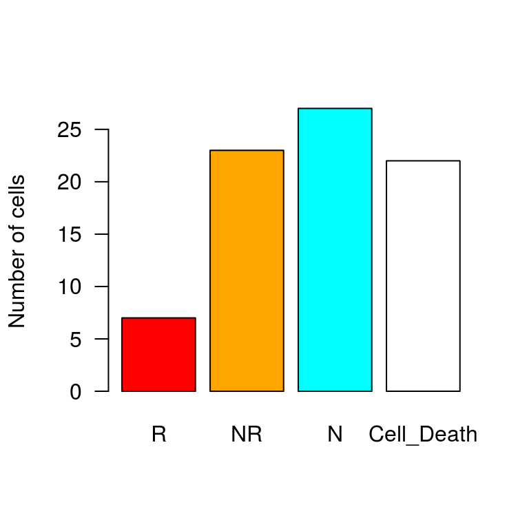

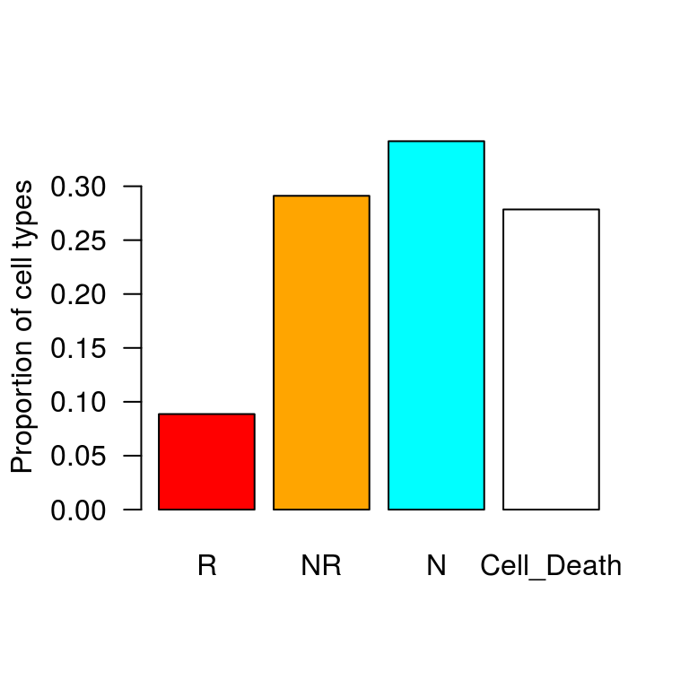

```r
barplot(myPropTab, beside = T,  names.arg = c("R","NR","N","Cell_Death"), las = 1, ylab = "Proportion of cell types", col = c("red", "orange", "cyan", "white"))
```

### Division table

In order to extract the joint information of the mother cell type and the daughter cell types, it is very handy to have a table with one row per division with the info of the mother cell and the 2 daughter cells on the same line. The function to generate such a table is `transformTreeIntoDivision`.

As argument this function takes a decodeData table (one row per cell per time point), and one needs to specify the `CellType` categories.

```r
myDivisionTable <- transformTreeIntoDivision(data2Transform = decodedDataExample, cellType = "simplified no death")  # option taking the type of the cell before cell death if it applies, check the help for more info
```

We also want to select for only the certain transitions and certain cell types (uncertainty of 1). There is the function `filterDivisionTable` to do this. Notice the second example of filter for the R cells using only the `R` syntax, this is actually what is behing the `filterDivisionTable` function.

```r
filteredDivisionTable  <- filterDivisionTable(divisionTable = myDivisionTable, uncertaintyType = c("1"), uncertaintyLineage = c("1")) # selecting cells with a certain type and certain lineage transitions

filteredDivisionTableRmother <-  filteredDivisionTable[filteredDivisionTable$MotherCellType == 1,] # selecting only the R cells as mother
```

Now we have our division table with the right cell type and the right uncertainty level. We can plot the heatmaps to display the frequencies of cell type transitions using the `getTransitionDiagram` function. There are quite a few arguments to chose which cell type category you want, which type of rank (normal or NR rank), the detail of the symmetry of the divisions. Try out different arguments and have a look at the results.

```r
resultsRankRmothers <- getTransitionDiagram(divisionTable = filteredDivisionTableRmother, cellType = "simplified no death", rank = "successive", detailedSymmetry = "TRUE")
```

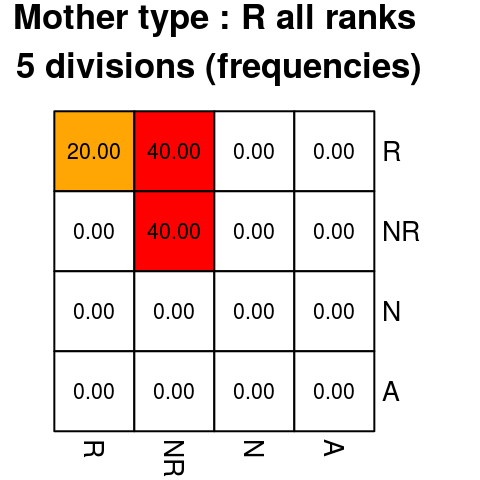

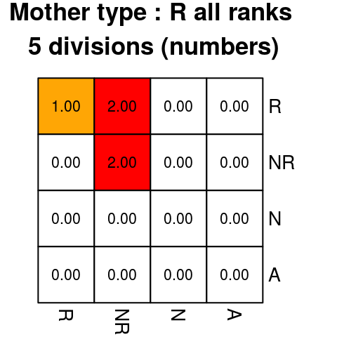

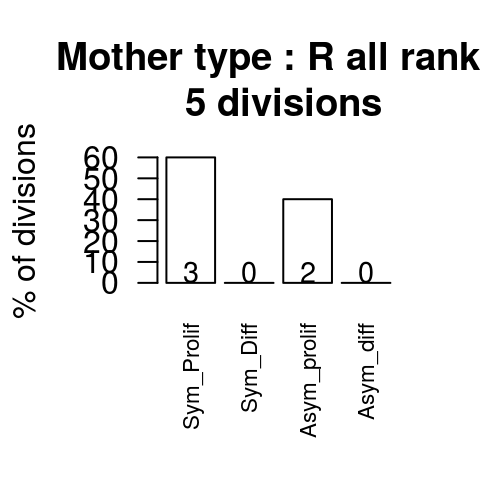

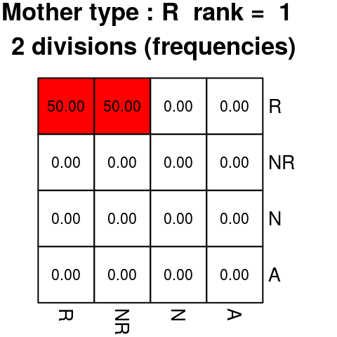

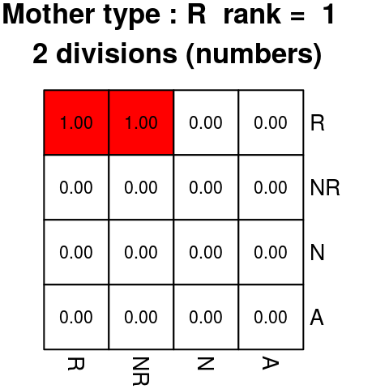

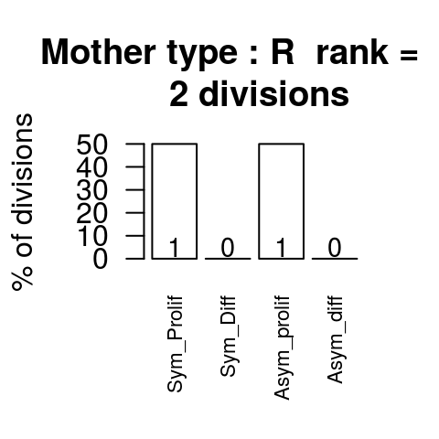

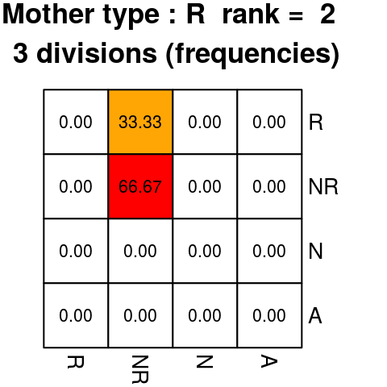

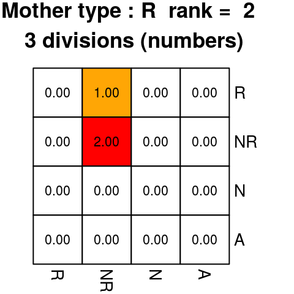

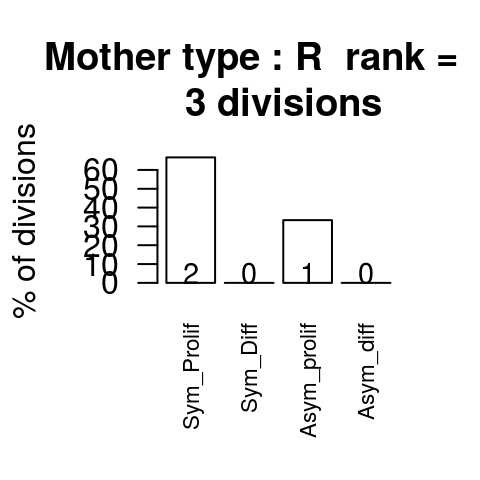

Note that the `getTransitionDiagram` function does not only outputs the heatmaps but also returns some tables with the exact numbers. In the example above, we saved the results in `resultsRankRmothers`. Looking at this object, you can notice that it contains different tables of different forms. It is actually a `list`. To access the different element you need to use `[[]]` instead of `[]`.

```r
resultsRankRmothers
```

```
## [[1]]
##      [,1] [,2]      [,3] [,4] [,5]
## [1,]  0.6  0.5 0.6666667   NA   NA
## [2,]  0.0  0.0 0.0000000   NA   NA
## [3,]  0.4  0.5 0.3333333   NA   NA
## [4,]  0.0  0.0 0.0000000   NA   NA
##
## [[2]]
##      [,1] [,2] [,3] [,4] [,5]
## [1,]    3    1    2   NA   NA
## [2,]    0    0    0   NA   NA
## [3,]    2    1    1   NA   NA
## [4,]    0    0    0   NA   NA
##
## [[3]]
## [1] "all" "1"   "2"   "3"   "4"
##
## [[4]]
## [1] "Sym_Prolif"  "Sym_Diff"    "Asym_prolif" "Asym_diff"
##
## [[5]]
## [1] 1
## Levels: 1 2 4 5
```

```r
resultsRankRmothers[[1]]
```

```
##      [,1] [,2]      [,3] [,4] [,5]
## [1,]  0.6  0.5 0.6666667   NA   NA
## [2,]  0.0  0.0 0.0000000   NA   NA
## [3,]  0.4  0.5 0.3333333   NA   NA
## [4,]  0.0  0.0 0.0000000   NA   NA
```

```r
resultsRankRmothers[[2]]
```

```
##      [,1] [,2] [,3] [,4] [,5]
## [1,]    3    1    2   NA   NA
## [2,]    0    0    0   NA   NA
## [3,]    2    1    1   NA   NA
## [4,]    0    0    0   NA   NA
```

`resultsRankRmothers[[1]]` contains the table of the proportions of the different division types for each cell type in the filtered `divisionTable`. The columns correspond to the ranks : all ranks, rank1, rank2 …

The rows correpond to the division types in this order: symmetric proliferative, symmetric differentiative, asymmetric proliferative, asymmetric differentiative

If there are more than 1 cell type in the input table, there will be 4 rows for each types. Let’s assume we have R and NR cells in the table. rows 1 to 4 will correspond to the division type proportions for the R cells, rows 5 to 8 to those of NR cells.

`resultsRankRmothers[[2]]` is organised the same way as `resultsRankRmothers[[1]]` expect that it gives the numbers of the different division types.

`resultsRankRmothers[[3]]` gives the names of the columns (the different ranks)

`resultsRankRmothers[[4]]` gives the names of the rows (the different division types, repeating for each cell type).

`resultsRankRmothers[[5]]` gives the names of the cell types in the table

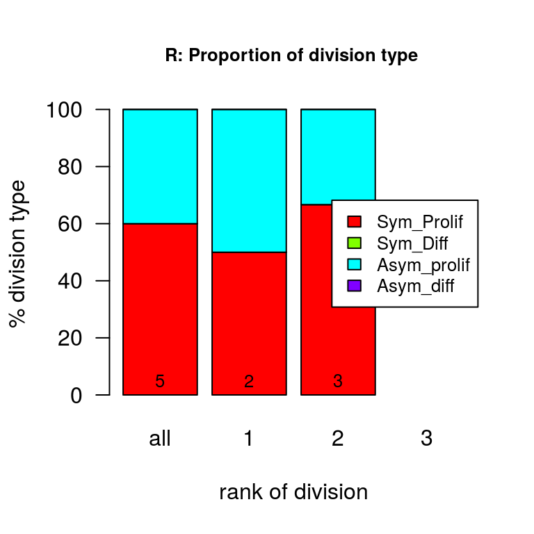

```r
symRank <- resultsRankRmothers[[1]]
nRank <-  resultsRankRmothers[[2]]
namesRank <-  resultsRankRmothers[[3]]
namesDiv <- resultsRankRmothers[[4]]
namesCellType <- resultsRankRmothers[[5]]

my.hist <- barplot(symRank[1:4,1:4]*100, names.arg = namesRank[1:4], main = paste("R: Proportion of division type "), las=1, ylab = "% division type", cex.main = 0.8, xlab = "rank of division", col = rainbow(4), beside = FALSE)

text(x = as.matrix(my.hist), y = 5,  labels = colSums(nRank[1:4,]), cex = .8)
legend("right",legend = namesDiv, fill = rainbow(4), cex = 0.8)
```

### Tc tables

To calculate the Tc, there is a function `getTc()` that returns a table with one Tc per line. For each line there is the information regarding one Tc:

infos about the mother cell, info about the cell which Tc is computed, info about the daughter cells generated by the cell whose Tc is being computed

The table contains the info of the division table with in addition this information:

- MotherDPI: the last DPI the mother is seen
- DaughterDPI: is the first DPI the daughter is seen (the Tc belongs to this cell)
- MotherDPI2: last DPI the daughter is seen
- DaughterDPI2: first DPI the great daughter is seen
- minTc: shortest possible Tc MotherDPI2 - DaughterDPI
- maxTc: the longest possible Tc DaughterDPI2 - MotherDPI
- windowTc: cumulated uncertainty of the corresponding 2 divisions (windowTc1: uncertainty duration for the first division birth of the Tc cell, windowTc2: uncertainty duration for the 2nd division corresponding to the division of the Tc cell).
- meanTc: mean between the min and maxTc of the cell defined by the D1ID

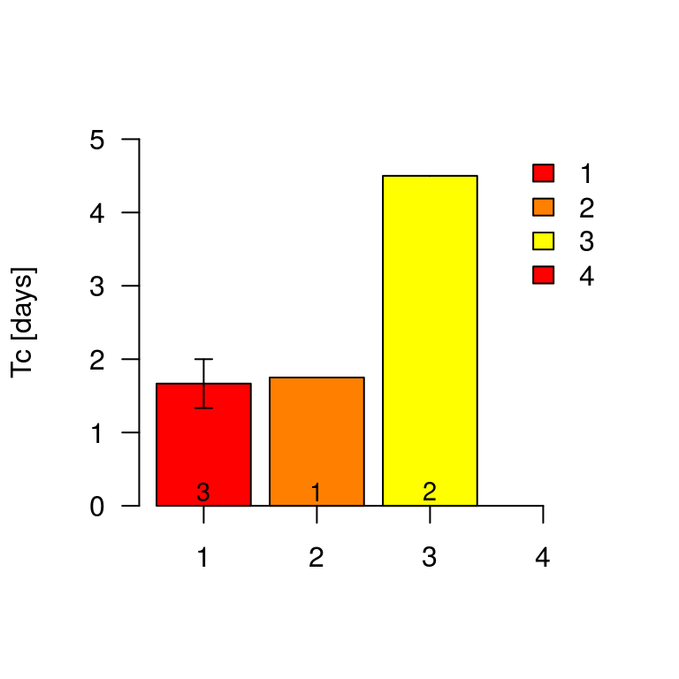

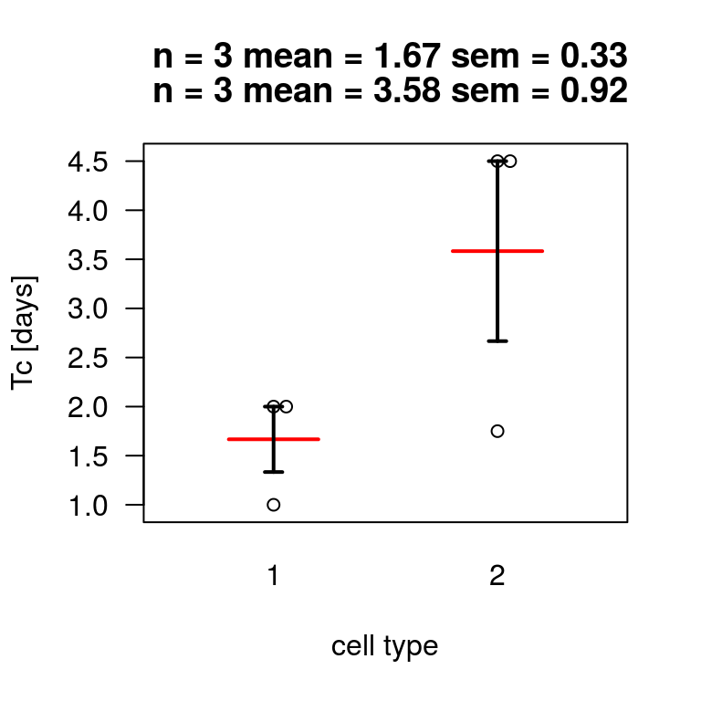

```r
# Generate the division table from the decodedData
divisionTable <- transformTreeIntoDivision(decodedDataExample, cellType = "simplified")

# Filters for uncertainty and types
myFilteredDivisionTable  <- filterDivisionTable(divisionTable, uncertaintyType = c("1","0.5","0"), uncertaintyLineage = c("1")) # takes all the uncertainties for the cell type but sure transitions
myFilteredDivisionTable <- myFilteredDivisionTable[myFilteredDivisionTable$MotherCellType != "5",]  # remove the astrocyte mother cell, if there is

# Generate the Tc table
tabTc <- getTc(filteredDivisionTable = myFilteredDivisionTable)

# Select only the realistic Tc (not too much uncertainty on the division windows of the 2 divisions)
thresholdDivisionWindow <- 6
tabTc <- tabTc[tabTc$totalWindowTc < thresholdDivisionWindow, ]   # filters for uncertainty time window
tabTc <- tabTc[tabTc$DaughterUncertaintyType ==1, ]               # filters for Tc whose cell type is certain

# Plot the Tc
  # Barplot:
TcmouseLine <- plotMeanTc(tabTc = tabTc, cond = list(tabTc$DivisionRank), ylim = c(0,5))
  # Barplotbeeswarm
barPlotBeeswarm(myData = data.frame(tabTc$meanTc,tabTc$DaughterCellType), xlab = "cell type", ylab = "Tc [days]")

# Retrieve all the Tc values for the different cell types
listTc <- with(tabTc, tapply(X = meanTc, INDEX = as.factor(DaughterCellType), FUN = identity))
```

### Death proportions functions

The death rate is defined as the frequency of dying leaves of the clones over the total number of leaves in the clone. The function to compute the death rate is `getDeathRate`. It takes as argument a table of the `dataMax` form containing only one clone. We will need to repeat the operation for every tree using a `for loop`. We can decide to also store the number of leaves for each tree and choose between “all” cell death or “early” cell death.

```r
# Get the ID of the different clones in the dataMax table
treeID <- unique(as.character(dataMax$Clone_uniqueID))

# Example for 1 tree
myTree <- dataMax[dataMax$Clone_uniqueID == treeID[1],] # select only the dataMax corresponding to the 1st tree

getDeathRate(treeDataMax = myTree, numberLeaves = T, deathType = "all")
```

```
##  DeathRate LeafNumber
##   22.72727   22.00000
## attr(,"lineageTree")
## [1] "gp519.SPOT3.clone1"
```

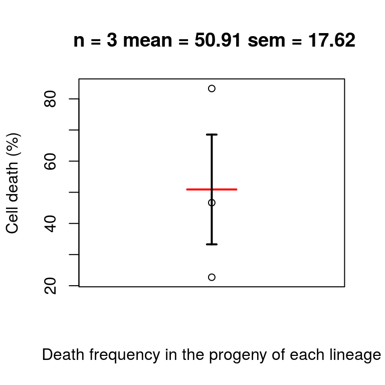

```r
######
# Code to compute the death Rate for each clone of the dataset:

# 1) Initialise the table where the death rates and number of leaves will be stored
deathRate <- data.frame(deathRate = c(1:length(treeID)), NumberLeaves = c(1:length(treeID)))

# 2) Loops for each value of treeID
for(i in c(1:length(treeID))){
  deathRate[i,] <- getDeathRate(treeDataMax = dataMax[dataMax$Clone_uniqueID == treeID[i],], numberLeaves = T, deathType = "all")
}

deathRate <- cbind(cloneID = treeID, deathRate) # Adds the information of the CloneID in the table, and potentially other relevant infor (mouseLine...)

# Plot the result
barPlotBeeswarm(deathRate$deathRate, xlab = "Death frequency in the progeny of each lineage", ylab = "Cell death (%)")
```

- Death rate in sublineages: `getDeathRateInSubtrees` function

```r
# Get the ID of the different clones in the dataMax table
treeID <- unique(as.character(dataMax$Clone_uniqueID))

# Example for 1 tree
myTree <- dataMax[dataMax$Clone_uniqueID == treeID[1],] # select only the dataMax corresponding to the 1st tree
getDeathRateInSubtrees(myTree, myDeathType = "early")   # Compute the death Rate in the different subtrees
```

| rank | deathRate | LeafNumber | motherRoot | root | rootCellType | rootCellTypeUncertainty |
| --- | --- | --- | --- | --- | --- | --- |
| 1 | 18.18182 | 22 | 0 | 1-1 | 1 | 2 |
| 2 | 50.00000 | 2 | 1-1 | 2-2 | 2 | 2 |
| 2 | 0.00000 | 3 | 1-1 | 2-3 | 2 | 2 |
| 2 | 0.00000 | 2 | 1-1 | 2-4 | 2 | 2 |
| 2 | 21.42857 | 14 | 1-1 | 2-1 | 1 | 2 |
| 2 | 0.00000 | 1 | 1-1 | 2-7 | 4 | 2 |
| 3 | 0.00000 | 2 | 2-3 | 3-4 | 2 | 2 |
| 3 | 0.00000 | 1 | 2-3 | 3-3 | 4 | 2 |
| 3 | 0.00000 | 2 | 2-1 | 3-9 | 2 | 2 |
| 3 | 50.00000 | 4 | 2-1 | 3-10 | 2 | 2 |

[output cut: 7 more lines]

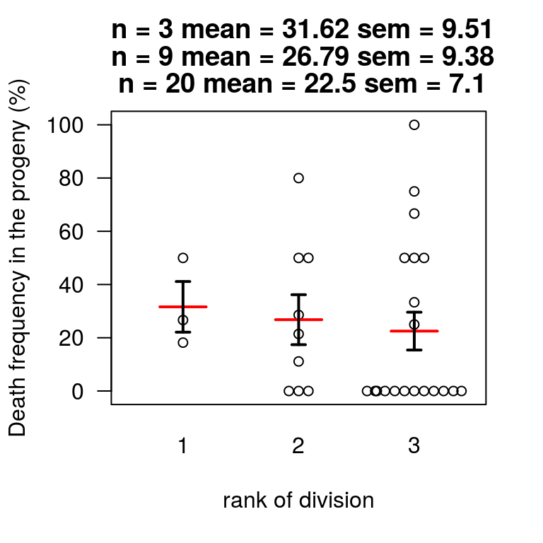

```r
# Code to compute the different death rates for each clone of the dataset

# 1) Initialise the table where the death rates and number of leaves will be stored
listCellDeathEarly <- data.frame() # table with cell death rate in whole tree and in different subtrees

for(i in 1:length(treeID)){
    myTree <- dataMax[dataMax$Clone_uniqueID == treeID[i],]   # Delect only the dataMax rows corresponding to a clone
    listCellDeathTemp <- data.frame(treeID = treeID[i], getDeathRateInSubtrees(myTree, myDeathType = "early")) # computes the different cell death in subtrees and add the treeID as a column for the current clone
    listCellDeathEarly <- rbind(listCellDeathEarly, listCellDeathTemp) # keep adding the new table below the old ones
}

listCellDeathEarly$rank <- as.numeric(listCellDeathEarly$rank)

barPlotBeeswarm(myData = data.frame(listCellDeathEarly$deathRate, listCellDeathEarly$rank), xlab = "rank of division", ylab = "Death frequency in the progeny (%)")
```

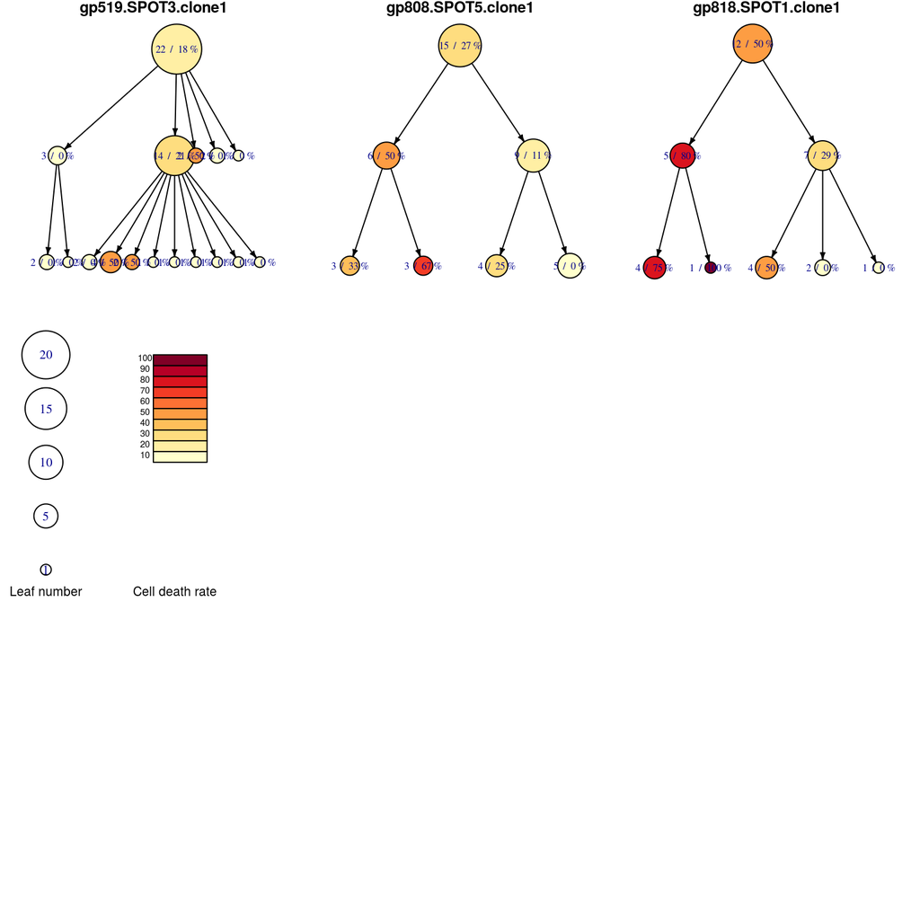

```r
treeVisualizationDeathRate(listCellDeath = listCellDeathEarly, saveGraph = F)
```